# HW2_21500268, ParkSeongchan

## Reading Data, Library

```r
load("C:/Users/Paul/Desktop/homework2_2020.RData")
head(cust.df)
```

```
##   state.of.res  custid sex is.employed Income       marital.stat health.ins
## 1      Alabama 1063014   F        TRUE     NA            Married       TRUE
## 2      Alabama 1192089   M          NA     NA            Married       TRUE
## 3      Alabama   16551   F          NA   4500            Married       TRUE
## 4      Alabama 1079878   F          NA  20000 Divorced/Separated       TRUE
## 5      Alabama  502705   M        TRUE  12000            Married      FALSE
## 6      Alabama  674271   M       FALSE 180000            Married       TRUE
##                   housing.type recent.move num.vehicles age
## 1                       Rented       FALSE            2  43
## 2     Homeowner free and clear       FALSE            2  77
## 3 Homeowner with mortgage/loan       FALSE            2  46
## 4 Homeowner with mortgage/loan       FALSE            1  62
## 5                       Rented       FALSE            4  37
## 6                       Rented        TRUE            1  54
```

```r
head(bankruptcy_df)
```

```
##   rownumber corpID                 index rating
## 1         1  c0001       Industrial Risk      P
## 2         2  c0001       Management Risk      P
## 3         3  c0001 Financial Flexibility      A
## 4         4  c0001           Credibility      A
## 5         5  c0001       Competitiveness      A
## 6         6  c0001        Operating Risk      P
```

```r
library(stringr)
library(tidyr)
library(lubridate)
```

데이터를 읽고, 2개의 Data frame을 확인한다.

또한 이번 작업에서 필요한 packages들을 불러온다.

### PART 1

## Question 1

```r
str(cust.df)
```

```
## 'data.frame':    1000 obs. of  11 variables:
##  $ state.of.res: chr  "Alabama" "Alabama" "Alabama" "Alabama" ...
##  $ custid      : int  1063014 1192089 16551 1079878 502705 674271 15917 467335 462569 1216026 ...
##  $ sex         : chr  "F" "M" "F" "F" ...
##  $ is.employed : logi  TRUE NA NA NA TRUE FALSE ...
##  $ Income      : num  NA NA 4500 20000 12000 180000 120000 40000 NA 24000 ...
##  $ marital.stat: chr  "Married" "Married" "Married" "Divorced/Separated" ...
##  $ health.ins  : logi  TRUE TRUE TRUE TRUE FALSE TRUE ...
##  $ housing.type: chr  "Rented" "Homeowner free and clear" "Homeowner with mortgage/loan" "Homeowner with mortgage/loan" ...
##  $ recent.move : logi  FALSE FALSE FALSE FALSE FALSE TRUE ...
##  $ num.vehicles: int  2 2 2 1 4 1 1 1 0 6 ...
##  $ age         : num  43 77 46 62 37 54 70 33 89 50 ...
```

```r
sapply(cust.df[1:11], class)
```

```
## state.of.res       custid          sex  is.employed       Income marital.stat
##  "character"    "integer"  "character"    "logical"    "numeric"  "character"
##   health.ins housing.type  recent.move num.vehicles          age
##    "logical"  "character"    "logical"    "integer"    "numeric"
```

str 함수를 통해서 데이터의 구조를 파악한다.

데이터의 observation은 1000개, variable은 11개이다.

각 variable의 타입은 sapply 함수를 통해 한번에 파악할 수 있다.

## Question 2

```r
str(cust.df)
```

```
## 'data.frame':    1000 obs. of  11 variables:
##  $ state.of.res: chr  "Alabama" "Alabama" "Alabama" "Alabama" ...
##  $ custid      : int  1063014 1192089 16551 1079878 502705 674271 15917 467335 462569 1216026 ...
##  $ sex         : chr  "F" "M" "F" "F" ...
##  $ is.employed : logi  TRUE NA NA NA TRUE FALSE ...
##  $ Income      : num  NA NA 4500 20000 12000 180000 120000 40000 NA 24000 ...
##  $ marital.stat: chr  "Married" "Married" "Married" "Divorced/Separated" ...
##  $ health.ins  : logi  TRUE TRUE TRUE TRUE FALSE TRUE ...
##  $ housing.type: chr  "Rented" "Homeowner free and clear" "Homeowner with mortgage/loan" "Homeowner with mortgage/loan" ...
##  $ recent.move : logi  FALSE FALSE FALSE FALSE FALSE TRUE ...
##  $ num.vehicles: int  2 2 2 1 4 1 1 1 0 6 ...
##  $ age         : num  43 77 46 62 37 54 70 33 89 50 ...
```

```r
cust.df$custid <- as.character(cust.df$custid)
cust.df$state.of.res <- as.factor(cust.df$state.of.res)
cust.df$sex <- as.factor(cust.df$sex)
cust.df$marital.stat <- as.factor(cust.df$marital.stat)
cust.df$housing.type <- as.factor(cust.df$housing.type)
```

str 함수를 통해서 현재 Data frame의 type을 확인한다.

1. custid 변수는 id를 의미하기 때문에 character로 변경한다. (3번 문제에서 character로 변환될 예정)
2. state.of.res 변수는는 약 50개의 미국의 주를 의미하므로 factor로 변경한다.
3. sex 변수는 남자와 여자라는 2개로 분류하므로 factor로 변경한다.
4. marital.stat 변수는 결혼과 관련된 상태로 분류하므로 factor로 변경한다.
5. housing.type 변수는 집 계약의 상태에 따라 분류하므로 factor로 변경한다.

## Question 3

```r
cust.df$custid <- str_pad(cust.df$custid, 7, 'left', pad = "0")
cust.df$custid <- str_pad(cust.df$custid, 8, 'left', pad = "c")

head(cust.df)
```

```
##   state.of.res   custid sex is.employed Income       marital.stat health.ins
## 1      Alabama c1063014   F        TRUE     NA            Married       TRUE
## 2      Alabama c1192089   M          NA     NA            Married       TRUE
## 3      Alabama c0016551   F          NA   4500            Married       TRUE
## 4      Alabama c1079878   F          NA  20000 Divorced/Separated       TRUE
## 5      Alabama c0502705   M        TRUE  12000            Married      FALSE
## 6      Alabama c0674271   M       FALSE 180000            Married       TRUE
##                   housing.type recent.move num.vehicles age
## 1                       Rented       FALSE            2  43
## 2     Homeowner free and clear       FALSE            2  77
## 3 Homeowner with mortgage/loan       FALSE            2  46
## 4 Homeowner with mortgage/loan       FALSE            1  62
## 5                       Rented       FALSE            4  37
## 6                       Rented        TRUE            1  54
```

먼저 가장 앞의 ’c’를 제외하고, str_pad 함수로 빈칸은 0으로 넣어서 7자리를 만들어준다.

그 후에 다시 한번 str_pad 함수를 사용해서 가장 앞에 ’c’를 붙여준다.

head 함수를 통해서 그 결과를 확인할 수 있다.

## Question 4

```r
num_of_NA <- colSums(is.na(cust.df))
num_of_not_NA <- colSums(!is.na(cust.df))

num_of_NA
```

```
## state.of.res       custid          sex  is.employed       Income marital.stat
##            0            0            0          328          328            0
##   health.ins housing.type  recent.move num.vehicles          age
##            0           56           56           56            0
```

```r
num_of_NA / (num_of_NA + num_of_not_NA)
```

```
## state.of.res       custid          sex  is.employed       Income marital.stat
##        0.000        0.000        0.000        0.328        0.328        0.000
##   health.ins housing.type  recent.move num.vehicles          age
##        0.000        0.056        0.056        0.056        0.000
```

colSums 함수를 통해 각 열 별로의 NA와 NA가 아닌 값들의 합을 구해서 각각 이름에 맞춰 할당한다.

각 변수별로 NA의 개수는 num_of_NA라는 변수를 통해 확인 할 수 있다.

또한 각 변수 별로의 비율은 NA에서 NA와 NA가 아닌 값들의 합을 나눠준다.

## Question 5

```r
summary(cust.df[, c(-4:-5)])
```

```
##        state.of.res    custid          sex                 marital.stat
##  California  :114   Length:1000        F:440   Divorced/Separated:155
##  New York    : 94   Class :character   M:560   Married           :516
##  Pennsylvania: 63   Mode  :character           Never Married     :233
##  Ohio        : 59                              Widowed           : 96
##  Illinois    : 52
##  Texas       : 51
##  (Other)     :567
##  health.ins                            housing.type recent.move
##  Mode :logical   Homeowner free and clear    :157   Mode :logical
##  FALSE:159       Homeowner with mortgage/loan:412   FALSE:820
##  TRUE :841       Occupied with no rent       : 11   TRUE :124
##                  Rented                      :364   NA's :56
##                  NA's                        : 56
##
##
##   num.vehicles        age
##  Min.   :0.000   Min.   :  0.0
##  1st Qu.:1.000   1st Qu.: 38.0
##  Median :2.000   Median : 50.0
##  Mean   :1.916   Mean   : 51.7
##  3rd Qu.:2.000   3rd Qu.: 64.0
##  Max.   :6.000   Max.   :146.7
##  NA's   :56
```

```r
table(rowSums(is.na(cust.df[, c(-4:-5)])))
```

```
##
##   0   3
## 944  56
```

NA가 10%가 넘는 변수들은 ‘is.employed’와 ’Income’ 이다. 따라서 이들을 제외한 Data frame을 사용한다.

이 Data frame에서 행을 기준으로 NA를 구하기 위해서 rowSums과 is.na 함수를 이용한다.

그리고 이것들이 같은 사람에게서 나왔는지 확인하기 위해 table 함수를 통해 전체로 확인해본다.

따라서 결국, NA가 10%가 넘지 않는 변수들에서 총 56명의 모두 동일한 고객들에게서 NA가 나왔음을 알 수 있다.

## Question 6

```r
cust.df$is.employed <- as.factor(cust.df$is.employed)

cust.df$is.employed <- ifelse(is.na(cust.df$is.employed) == TRUE, "missing",
                              ifelse(cust.df$is.employed == "TRUE", "employed", "not employed"))

table(cust.df$is.employed)
```

```
##
##     employed      missing not employed
##          599          328           73
```

먼저 기존에 logical type에서 factor type으로 변환시킨다.

그 후, ifelse 함수를 통해서 NA인 경우에는 ‘missing’으로, TRUE는 ’employed’, FALSE는 ’not employed’로 할당한다.

이 과정을 통해 table 함수로 전체를 확인해보면, 새롭게 할당한 3개의 값으로 바뀐 것을 볼 수 있다.

## Question 7

```r
median.income <- aggregate(Income ~ state.of.res, cust.df, median)
mean.income <- aggregate(Income ~ state.of.res, cust.df, mean)

avg_income <- cbind(median.income, mean.income)
avg_income <- avg_income[, c(1, 2, 4)]

names(avg_income)[2:3] <- ifelse(names(avg_income)[2:3] == "Income", "median.income", "mean.income")

head(avg_income)
```

```
##   state.of.res median.income mean.income
## 1      Alabama         32000    77562.50
## 2       Alaska         87100    87100.00
## 3      Arizona         60000    95040.00
## 4     Arkansas         25800    35911.43
## 5   California         47500    73534.44
## 6     Colorado         46750    48683.33
```

aggregate 함수를 통해서 state.of.res 기준으로 Income의 median과 mean을 구해서 각각의 새로운 Data frame에 할당한다.

그리고 cbind를 통해서 두 Data frame을 붙이고, 3번째 열에 있는 state.of.res가 중복되므로 이를 제외시킨 avg_income을 만든다.

그리고 열의 이름을 ’median.income’과 ’mean.income’으로 수정한다.

head 함수를 통해서 그 결과를 확인할 수 있다.

## Question 8

```r
cust.df <- merge(cust.df, avg_income, by = 'state.of.res')
cust.df$Income <- ifelse(is.na(cust.df$Income), cust.df$mean.income, cust.df$Income)
sum(is.na(cust.df$Income))
```

```
## [1] 0
```

merge 함수로 ‘state.of.res’ 변수를 기준으로 cust.df와 avg_income이라는 두 Data frame을 병합한다.

그리고 ifelse 함수를 통해 Income 변수에서 NA인 값을 mean.income 값으로 대체한다.

이를 통해 is.na의 합이 0인 것을 볼 수 있다.

## Question 9

```r
cust.df$income.relative <- cust.df$Income / cust.df$median.income
head(cust.df)
```

```
##   state.of.res   custid sex  is.employed   Income       marital.stat health.ins
## 1      Alabama c1192089   M      missing  77562.5            Married       TRUE
## 2      Alabama c0016551   F      missing   4500.0            Married       TRUE
## 3      Alabama c0674271   M not employed 180000.0            Married       TRUE
## 4      Alabama c0015917   F     employed 120000.0 Divorced/Separated       TRUE
## 5      Alabama c1079878   F      missing  20000.0 Divorced/Separated       TRUE
## 6      Alabama c0502705   M     employed  12000.0            Married      FALSE
##                   housing.type recent.move num.vehicles age median.income
## 1     Homeowner free and clear       FALSE            2  77         32000
## 2 Homeowner with mortgage/loan       FALSE            2  46         32000
## 3                       Rented        TRUE            1  54         32000
## 4     Homeowner free and clear       FALSE            1  70         32000
## 5 Homeowner with mortgage/loan       FALSE            1  62         32000
## 6                       Rented       FALSE            4  37         32000
##   mean.income income.relative
## 1     77562.5        2.423828
## 2     77562.5        0.140625
## 3     77562.5        5.625000
## 4     77562.5        3.750000
## 5     77562.5        0.625000
## 6     77562.5        0.375000
```

각 사람들의 Income과 median.income으로 나눈 것을 cust.df의 새로운 변수 income.relative에 할당한다.

그리고 head 함수를 통해 확인하면 가장 마지막 열에 추가된 것을 볼 수 있다.

## Question 10, 11

```r
summary(cust.df)
```

```
##        state.of.res    custid          sex     is.employed
##  California  :114   Length:997         F:440   Length:997
##  New York    : 94   Class :character   M:557   Class :character
##  Pennsylvania: 63   Mode  :character           Mode  :character
##  Ohio        : 59
##  Illinois    : 52
##  Texas       : 51
##  (Other)     :564
##      Income                   marital.stat health.ins
##  Min.   : -8700   Divorced/Separated:155   Mode :logical
##  1st Qu.: 35000   Married           :515   FALSE:159
##  Median : 54031   Never Married     :232   TRUE :838
##  Mean   : 65564   Widowed           : 95
##  3rd Qu.: 75286
##  Max.   :615000
##
##                        housing.type recent.move      num.vehicles
##  Homeowner free and clear    :156   Mode :logical   Min.   :0.000
##  Homeowner with mortgage/loan:411   FALSE:817       1st Qu.:1.000
##  Occupied with no rent       : 11   TRUE :124       Median :2.000
##  Rented                      :363   NA's :56        Mean   :1.917
##  NA's                        : 56                   3rd Qu.:2.000
##                                                     Max.   :6.000
##                                                     NA's   :56
##       age        median.income     mean.income     income.relative
##  Min.   :  0.0   Min.   : 10000   Min.   : 10000   Min.   :-0.1812
##  1st Qu.: 38.0   1st Qu.: 40000   1st Qu.: 52029   1st Qu.: 0.7719
##  Median : 50.0   Median : 45000   Median : 66042   Median : 1.2632
##  Mean   : 51.7   Mean   : 47421   Mean   : 65564   Mean   : 1.4006
##  3rd Qu.: 64.0   3rd Qu.: 53000   3rd Qu.: 73534   3rd Qu.: 1.5481
##  Max.   :146.7   Max.   :194000   Max.   :194000   Max.   : 9.6250
##
```

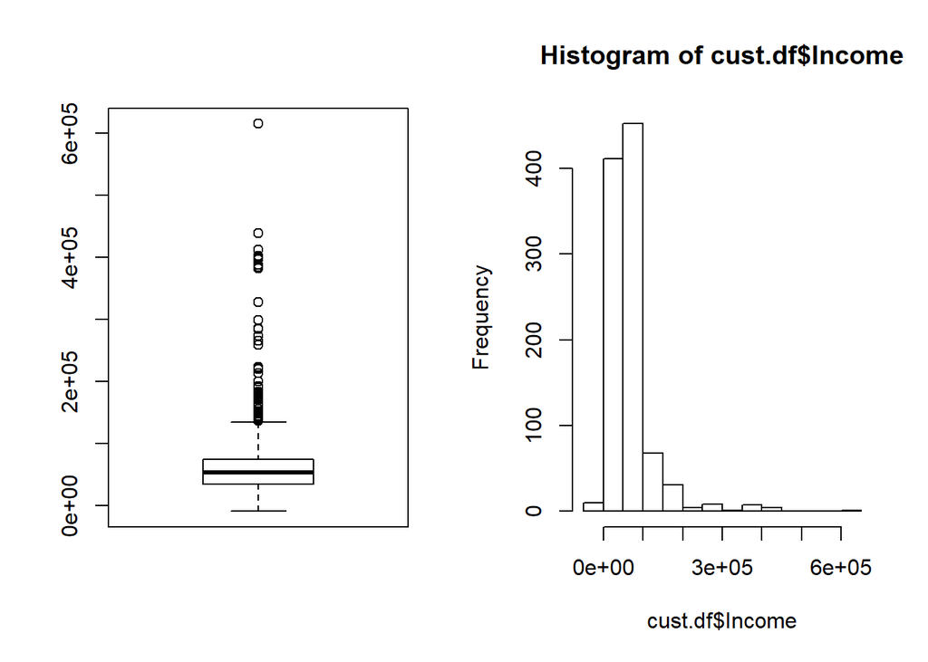

```r
par(mfrow = c(1, 2))
boxplot(cust.df$Income)
hist(cust.df$Income)
```

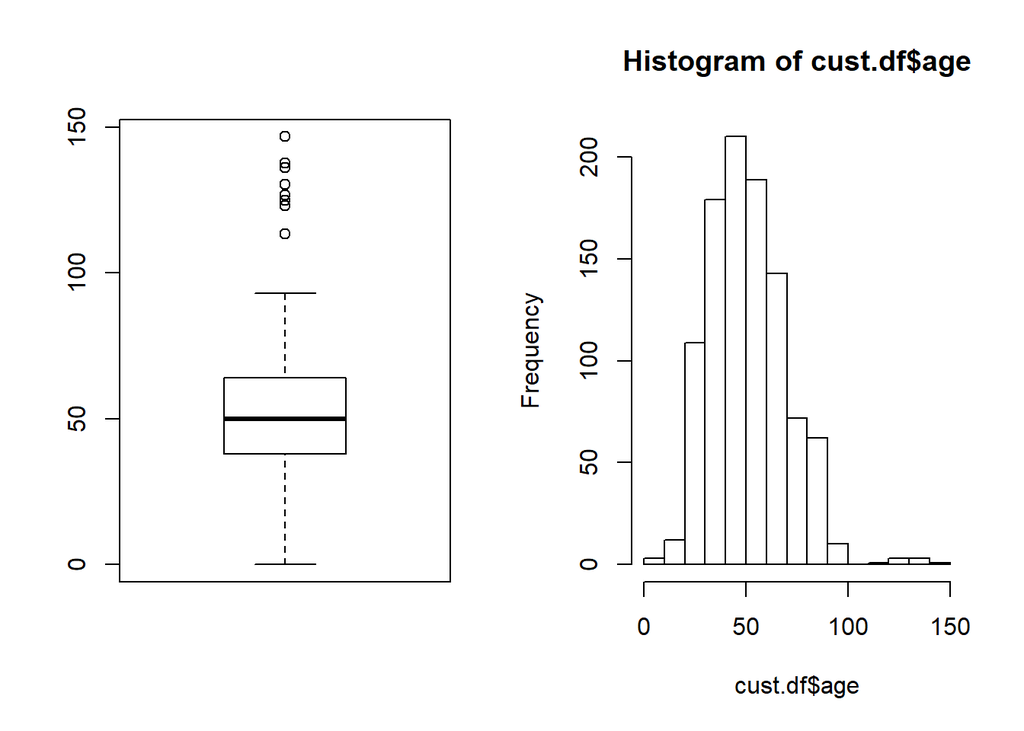

```r
boxplot(cust.df$age)
hist(cust.df$age)
```

summary 함수를 통해서 cust.df를 전체적으로 확인한다.

1. 소득을 의미하는 Income이 음수의 값을 가질 수 없으므로 명백한 오류이다.
2. 나이를 의미하는 age가 0살을 의미하는 것이 정확히 무엇인지 확인이 필요하다.
3. 나이를 의미하는 age가 146.7살이 가능한지에 대해서 정확히 확인이 필요하다.

### PART 2

## Question 1

```r
head(bankruptcy_df)
```

```
##   rownumber corpID                 index rating
## 1         1  c0001       Industrial Risk      P
## 2         2  c0001       Management Risk      P
## 3         3  c0001 Financial Flexibility      A
## 4         4  c0001           Credibility      A
## 5         5  c0001       Competitiveness      A
## 6         6  c0001        Operating Risk      P
```

이 Data frame은 tidy data가 아니다.

그 이유는 index 열은 variables 형태를 가지고 있으므로 Columns으로 들어가야 한다.

무의미한 rownumber가 들어가 있다.

## Question 2

```r
bankruptcy_df <- bankruptcy_df[2:4]
bankruptcy_df <- spread(bankruptcy_df, index, rating)
head(bankruptcy_df)
```

```
##   corpID Class Competitiveness Credibility Financial Flexibility
## 1  c0001    NB               A           A                     A
## 2  c0002    NB               A           A                     A
## 3  c0003    NB               A           A                     A
## 4  c0004    NB               P           P                     P
## 5  c0005    NB               P           P                     P
## 6  c0006    NB               P           P                     P
##   Industrial Risk Management Risk Operating Risk
## 1               P               P              P
## 2               N               N              N
## 3               A               A              A
## 4               P               P              P
## 5               N               N              N
## 6               A               A              A
```

```r
save(bankruptcy_df, file = '~/bankruptcy_df_tidy.RData')
```

먼저 무의미한 첫번째 열을 제외한다.

그리고 spread 함수를 통해서 index를 KEY로, rating을 VAL로 바꿔서 tidy한 형태로 변환하다.

그리고 save를 통해 RData 파일로 저장한다.

## Question 3

```r
bankruptcy_df[2:8] <- ifelse(bankruptcy_df[2:8] == 'P', 'Positive',
                             ifelse(bankruptcy_df[2:8] == 'A', 'Average',
                                    ifelse(bankruptcy_df[2:8] == 'N', 'negative',
                                           ifelse(bankruptcy_df[2:8] == 'B', 'Bankruptcy', 'Non-Bankruptcy'))))

head(bankruptcy_df)
```

```
##   corpID          Class Competitiveness Credibility Financial Flexibility
## 1  c0001 Non-Bankruptcy         Average     Average               Average
## 2  c0002 Non-Bankruptcy         Average     Average               Average
## 3  c0003 Non-Bankruptcy         Average     Average               Average
## 4  c0004 Non-Bankruptcy        Positive    Positive              Positive
## 5  c0005 Non-Bankruptcy        Positive    Positive              Positive
## 6  c0006 Non-Bankruptcy        Positive    Positive              Positive
##   Industrial Risk Management Risk Operating Risk
## 1        Positive        Positive       Positive
## 2        negative        negative       negative
## 3         Average         Average        Average
## 4        Positive        Positive       Positive
## 5        negative        negative       negative
## 6         Average         Average        Average
```

ifelse 함수를 통해서 ‘P’는 ’Positive’, ‘A’는 ’Average’, ‘N’은 ’negative’, ‘B’는 ’Bankruptcy’, ’NB’는 ’Non-Bankruptcy’로 변환한다.

그리고 head 함수를 통해서 그 결과를 확인할 수 있다.